# HW6 - Summarizing Data

Daniel Craig

2022-06-13

```r
crabsData <- read_table("C:/Users/dcraig/Documents/Repos/d-ev-craig.github.io/_HW/HW6 - Summarizing Data/crabs.txt", col_types = list('f','f','d','d','d','f','f'))
crabsData
```

```
## # A tibble: 173 × 7
##    color spine width satell weight y     X7
##    <fct> <fct> <dbl>  <dbl>  <dbl> <fct> <fct>
##  1 3     3      28.3      8   3050 1     <NA>
##  2 4     3      22.5      0   1550 0     <NA>
##  3 2     1      26        9   2300 1     <NA>
##  4 4     3      24.8      0   2100 0     <NA>
##  5 4     3      26        4   2600 1     <NA>
##  6 3     3      23.8      0   2100 0     <NA>
##  7 2     1      26.5      0   2350 0     <NA>
##  8 4     2      24.7      0   1900 0     <NA>
##  9 3     1      23.7      0   1950 0     <NA>
## 10 4     3      25.6      0   2150 0     <NA>
## # … with 163 more rows
```

```r
crabsData <- crabsData[1:6]


levels(crabsData$color) <- c("medium","dark","light","darker")

#crabsData$color <- ordered(crabsData$color, levels = c("light","medium","dark","darker"))

levels(crabsData$spine) <- c("both worn or broken","both good","one worn or broken")
#crabsData$spine <- ordered(crabsData$spine, levels = c("both good","one worn or broken","both worn or broken"))

levels(crabsData$y) <- c("At least 1 Sattelite","No Satellite")
#crabsData$y <- ordered(crabsData$y, levels = c("No Satellite","At least 1 Sattelite"))

crabsData
```

```
## # A tibble: 173 × 6
##    color  spine               width satell weight y
##    <fct>  <fct>               <dbl>  <dbl>  <dbl> <fct>
##  1 medium both worn or broken  28.3      8   3050 At least 1 Sattelite
##  2 dark   both worn or broken  22.5      0   1550 No Satellite
##  3 light  both good            26        9   2300 At least 1 Sattelite
##  4 dark   both worn or broken  24.8      0   2100 No Satellite
##  5 dark   both worn or broken  26        4   2600 At least 1 Sattelite
##  6 medium both worn or broken  23.8      0   2100 No Satellite
##  7 light  both good            26.5      0   2350 No Satellite
##  8 dark   one worn or broken   24.7      0   1900 No Satellite
##  9 medium both good            23.7      0   1950 No Satellite
## 10 dark   both worn or broken  25.6      0   2150 No Satellite
## # … with 163 more rows
```

2. Create a one-way contingency table of the spine variable using the table() function

```r
table(crabsData$spine)
```

```
##
## both worn or broken           both good  one worn or broken
##                 121                  37                  15
```

3. Recreate the above one-way table using tidyverse functions. Hint: group_by() and summarize() can be used with the n() function to do the counting.

```r
cD <- crabsData %>% group_by(crabsData$spine)
cD %>% summarise(n())
```

```
## # A tibble: 3 × 2
##   `crabsData$spine`   `n()`
##   <fct>               <int>
## 1 both worn or broken   121
## 2 both good              37
## 3 one worn or broken     15
```

4. Create a two-way contingency table between the satellite and spine variables using the table() function. Write text describing what two of the numbers in the table represent.

```r
table(crabsData$satell,crabsData$spine)
```

```
##
##      both worn or broken both good one worn or broken
##   0                   43        11                  8
##   1                   13         3                  0
##   2                    8         1                  0
##   3                   15         2                  2
##   4                   12         4                  3
##   5                    8         7                  0
##   6                    8         3                  2
##   7                    3         1                  0
##   8                    4         2                  0
##   9                    1         2                  0
##   10                   3         0                  0
##   11                   1         0                  0
##   12                   1         0                  0
##   14                   0         1                  0
##   15                   1         0                  0
```

We can see the frequency at which female crabs have broken or worn spines for every level of satellites. For example, at 0 satellites, there were 11 female crabs that had either a both good level of spine; 8 female crabs had either one worn or broken spine; 43 female crabs had either both worn or broken spines.

5.Recreate the above two-way table using tidyverse functions. Make the final table print out in a wide format using pivot_wider().

```r
cD_satvspine <- crabsData %>% group_by(spine,satell)
cD_satvspine
```

```
## # A tibble: 173 × 6
## # Groups:   spine, satell [29]
##    color  spine               width satell weight y
##    <fct>  <fct>               <dbl>  <dbl>  <dbl> <fct>
##  1 medium both worn or broken  28.3      8   3050 At least 1 Sattelite
##  2 dark   both worn or broken  22.5      0   1550 No Satellite
##  3 light  both good            26        9   2300 At least 1 Sattelite
##  4 dark   both worn or broken  24.8      0   2100 No Satellite
##  5 dark   both worn or broken  26        4   2600 At least 1 Sattelite
##  6 medium both worn or broken  23.8      0   2100 No Satellite
##  7 light  both good            26.5      0   2350 No Satellite
##  8 dark   one worn or broken   24.7      0   1900 No Satellite
##  9 medium both good            23.7      0   1950 No Satellite
## 10 dark   both worn or broken  25.6      0   2150 No Satellite
## # … with 163 more rows
```

```r
cD_satvspine %>% summarise(n()) %>% pivot_wider(names_from = "spine", values_from = "n()", values_fill = 0)
```

```
## # A tibble: 15 × 4
##    satell `both worn or broken` `both good` `one worn or broken`
##     <dbl>                 <int>       <int>                <int>
##  1      0                    43          11                    8
##  2      1                    13           3                    0
##  3      2                     8           1                    0
##  4      3                    15           2                    2
##  5      4                    12           4                    3
##  6      5                     8           7                    0
##  7      6                     8           3                    2
##  8      7                     3           1                    0
##  9      8                     4           2                    0
## 10      9                     1           2                    0
## 11     10                     3           0                    0
## 12     11                     1           0                    0
## 13     12                     1           0                    0
## 14     15                     1           0                    0
## 15     14                     0           1                    0
```

6. Create a three way table between the color, spine, and satellite variables using the table() function. Output the table. Then, using that table object, print out a two-way table between spine and satellite for crabs with ‘darker’ color. Write text describing what one of the numbers in the table represents.

```r
OohLaLa <-table(crabsData$color,crabsData$spine,crabsData$satell)
OohLaLa
```

```
## , ,  = 0
##
##
##          both worn or broken both good one worn or broken
##   medium                  13         8                  5
##   dark                    16         0                  2
##   light                    1         2                  0
##   darker                  13         1                  1
##
## , ,  = 1
##
##
##          both worn or broken both good one worn or broken
##   medium                   8         3                  0
##   dark                     5         0                  0
##   light                    0         0                  0
##   darker                   0         0                  0
##
## , ,  = 2
##
##
##          both worn or broken both good one worn or broken
##   medium                   6         0                  0
##   dark                     2         0                  0
##   light                    0         1                  0
##   darker                   0         0                  0
##
## , ,  = 3
##
##
##          both worn or broken both good one worn or broken
##   medium                   8         1                  0
##   dark                     5         1                  1
##   light                    0         0                  1
##   darker                   2         0                  0
##
## , ,  = 4
##
##
##          both worn or broken both good one worn or broken
```

[output cut: 79 more lines]

```
##
##          both worn or broken both good one worn or broken
##   medium                   0         1                  0
##   dark                     0         0                  0
##   light                    0         0                  0
##   darker                   0         0                  0
##
## , ,  = 15
##
##
##          both worn or broken both good one worn or broken
##   medium                   1         0                  0
##   dark                     0         0                  0
##   light                    0         0                  0
##   darker                   0         0                  0
```

```r
tab <- OohLaLa
str(tab)
```

```
##  'table' int [1:4, 1:3, 1:15] 13 16 1 13 8 0 2 1 5 2 ...
##  - attr(*, "dimnames")=List of 3
##   ..$ : chr [1:4] "medium" "dark" "light" "darker"
##   ..$ : chr [1:3] "both worn or broken" "both good" "one worn or broken"
##   ..$ : chr [1:15] "0" "1" "2" "3" ...
```

```r
tab[4,,]
```

```
##
##                        0  1  2  3  4  5  6  7  8  9 10 11 12 14 15
##   both worn or broken 13  0  0  2  1  1  0  0  1  0  1  0  1  0  0
##   both good            1  0  0  0  0  0  0  0  0  0  0  0  0  0  0
##   one worn or broken   1  0  0  0  0  0  0  0  0  0  0  0  0  0  0
```

For female crabs with a color of darker, and having 0 satellites, there was only one crab with both spines good, one crab with one spine worn or broken, and thirteen crabs with both spines worn or broken.

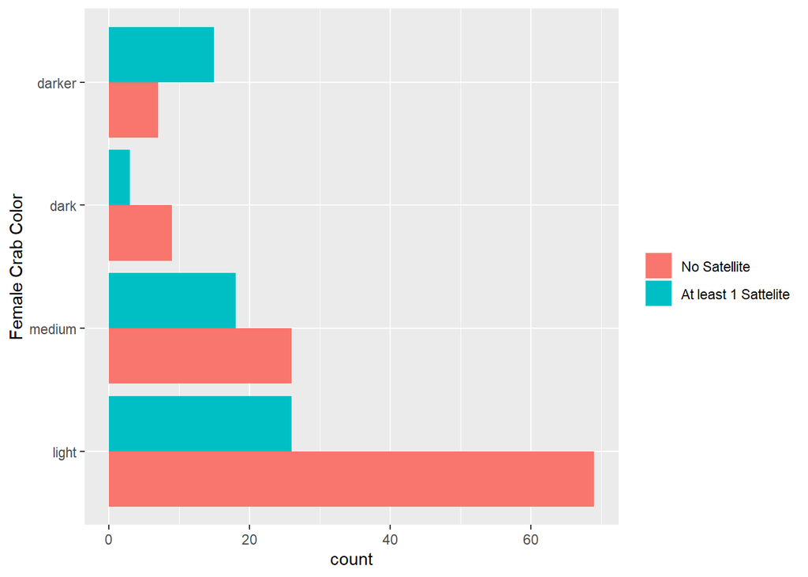

```r
ColorvSatell <- ggplot(crabsData, aes(x = color))
ColorvSatell + geom_bar(aes(fill = as.factor(y)), position = "dodge")+ labs(x = "Female Crab Color") +   scale_x_discrete(labels = c("light","medium","dark","darker"))+
  scale_fill_discrete(name = "",labels = c("No Satellite","At least 1 Sattelite"))+
  coord_flip()
```

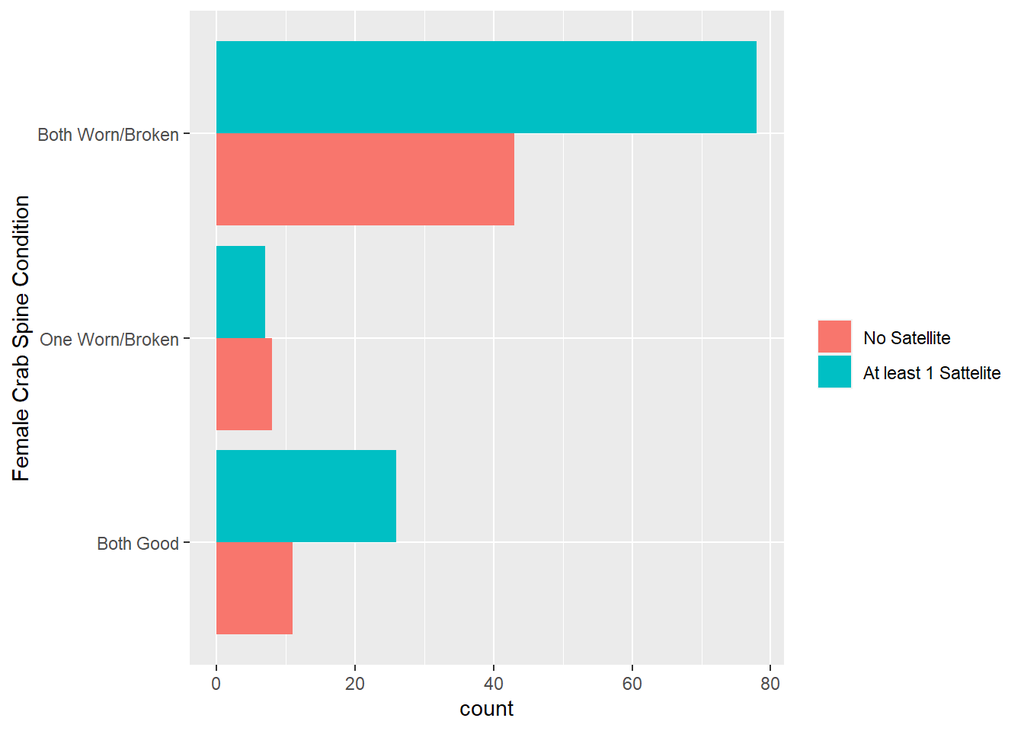

```r
#this was blowing my mind for so long

crabsDataBroke <- crabsData


crabsDataBroke$y <- ordered(crabsDataBroke$y, levels = c('No Satellite','At least 1 Sattelite'))


crabsDataBroke$spine <- ordered(crabsDataBroke$spine, levels = c('both good','one worn or broken','both worn or broken'))


SpinevSatell <- ggplot(crabsDataBroke, aes(x = spine))
SpinevSatell + geom_bar(aes(fill = as.factor(y)), position = "dodge")+ labs(x = "Female Crab Spine Condition") + scale_x_discrete(labels = c("Both Good","One Worn/Broken","Both Worn/Broken"))+
  scale_fill_discrete(name = "",labels = c("No Satellite","At least 1 Sattelite"))+
  coord_flip()
```

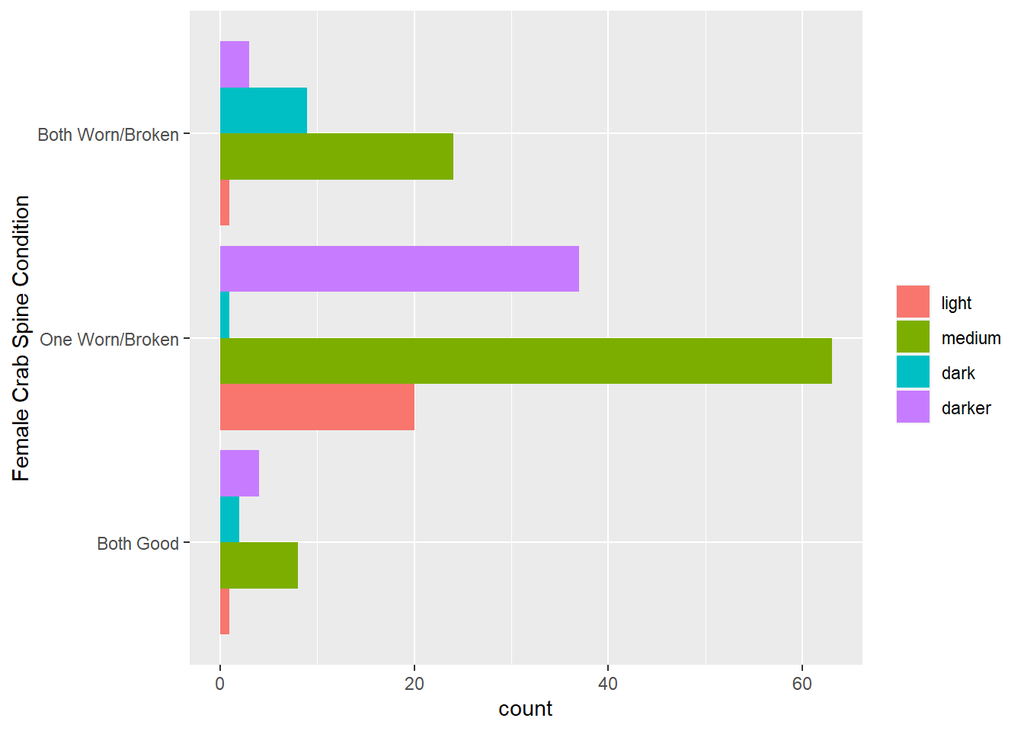

```r
# Please stop making me do this
crabsDataBrokev2 <- crabsData

crabsDataBrokev2$spine <- ordered(crabsDataBrokev2$spine, levels = c('one worn or broken','both worn or broken','both good'))

crabsDataBrokev2$color <- ordered(crabsDataBrokev2$color, levels = c('darker','medium','light','dark'))

SpinevColor <- ggplot(crabsDataBrokev2, aes(x = spine))
SpinevColor + geom_bar(aes(fill = as.factor(color)), position = "dodge")+ labs(x = "Female Crab Spine Condition") + scale_x_discrete(labels = c("Both Good","One Worn/Broken","Both Worn/Broken"))+
  scale_fill_discrete(name = "",labels = c("light","medium","dark","darker"))+
  coord_flip()
```

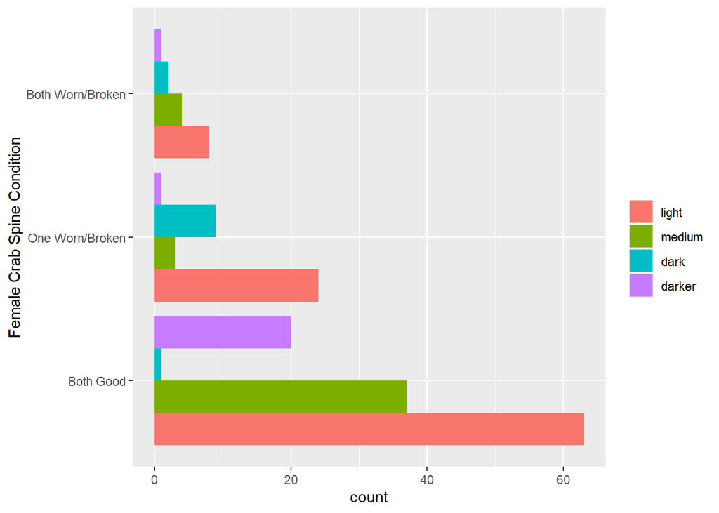

```r
SpinevColor <- ggplot(crabsData, aes(x = spine))
SpinevColor + geom_bar(aes(fill = as.factor(color)), position = "dodge")+ labs(x = "Female Crab Spine Condition") + scale_x_discrete(labels = c("Both Good","One Worn/Broken","Both Worn/Broken"))+
  scale_fill_discrete(name = "",labels = c("light","medium","dark","darker"))+
  coord_flip()
```

9. Recreate the summary statistics below. Write text that interprets one of the sets of summary stats.

```r
crabsData$color <- ordered(crabsData$color, levels = c('light','medium','dark','darker'))
crabsData$y <- ordered(crabsData$y, levels = c('No Satellite','At least 1 Sattelite'))
crabsData %>% group_by(color, y) %>% summarise(Avg = round(mean(weight)), sd = round(sd(weight)), med = round(median(weight)), IQR = round(IQR(weight)))
```

```
## # A tibble: 8 × 6
## # Groups:   color [4]
##   color  y                      Avg    sd   med   IQR
##   <ord>  <ord>                <dbl> <dbl> <dbl> <dbl>
## 1 light  No Satellite          2525   152  2600   138
## 2 light  At least 1 Sattelite  2664   442  2700   650
## 3 medium No Satellite          2242   482  2200   512
## 4 medium At least 1 Sattelite  2649   615  2700   800
## 5 dark   No Satellite          1907   348  1900   462
## 6 dark   At least 1 Sattelite  2571   495  2575   719
## 7 darker No Satellite          2162   436  2150   650
## 8 darker At least 1 Sattelite  2200   523  2100   200
```

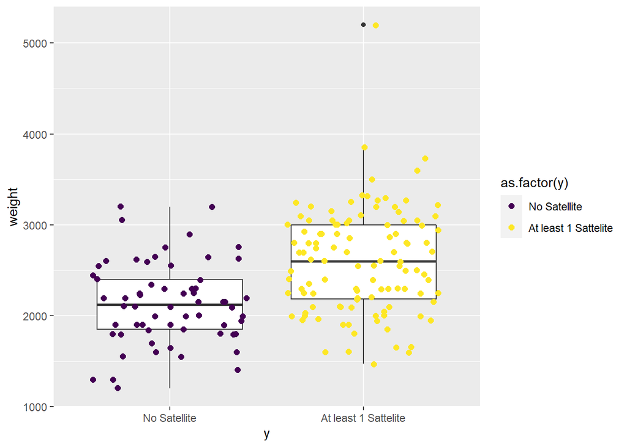

```r
crabsData$y <- ordered(crabsData$y, levels = c('No Satellite','At least 1 Sattelite'))

WeightvSatel <- ggplot(crabsData, aes(x = y, y = weight))
WeightvSatel + geom_boxplot(fill = "white",position ="dodge") + geom_jitter(aes(color = as.factor(y)),size =2)
```

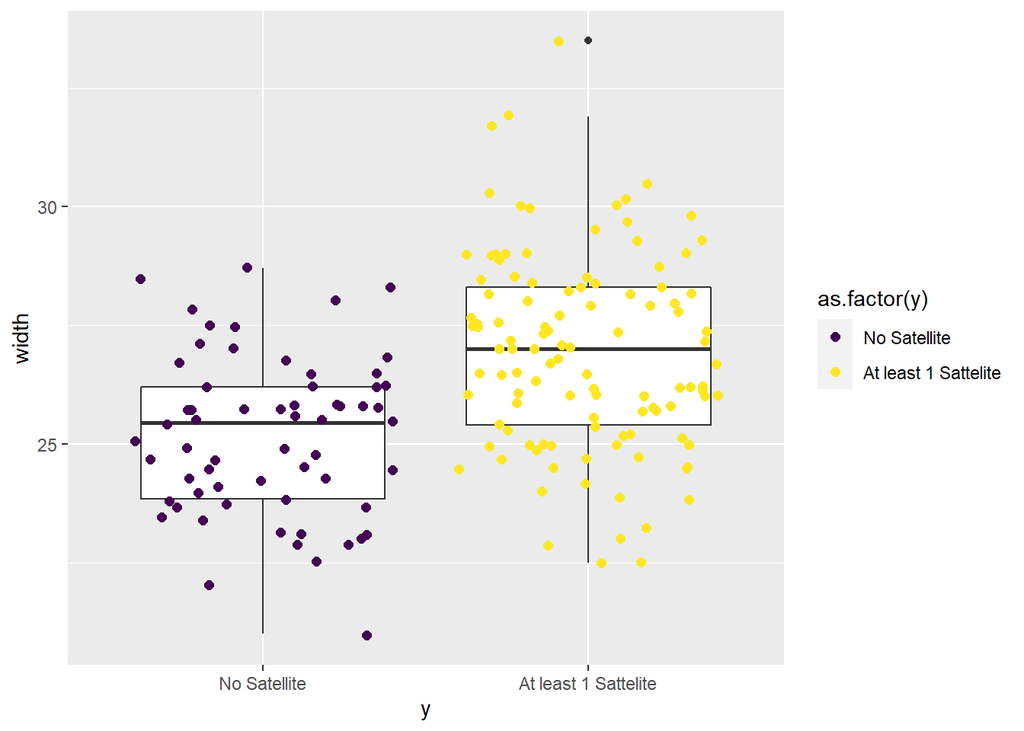

```r
WidthvSatel <- ggplot(crabsData, aes(x = y, y = width))
WidthvSatel + geom_boxplot(fill = "white",position ="dodge") + geom_jitter(aes(color = as.factor(y)),size =2)+scale_fill_discrete(name = "y",labels = 'No Satellite','At least 1 Sattelite')
```

```r
cor(crabsData$weight, crabsData$width)
```

```
## [1] 0.8868715
```

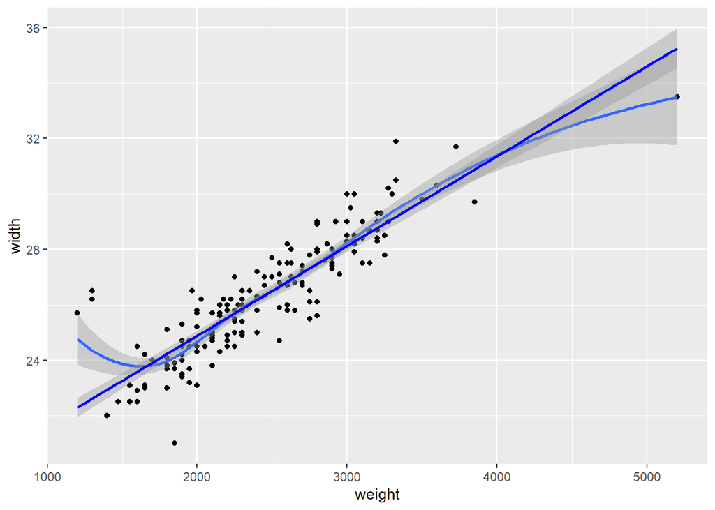

```r
WeightvWidth <- ggplot(crabsData, aes(x = weight, y = width))
WeightvWidth + geom_point() + geom_smooth() + geom_smooth(method = lm, col="blue")
```